# Projekt OSP - Spotify Songs

0036539445 Filip Buhinićek, 0036542400 Dominik Zoričić, 0036539188 Nikola Botić

2024-01-26

## UVOD

Ovaj skup podataka pruža opsežnu zbirku pjesama s nizom atributa, uključujući, ali ne ograničavajući se na, popularnost pjesme, žanr, pojedinosti o izvođaču i niz akustičnih značajki poput tempa, energije itd. Ovi atributi omogućuju višestruku analizu, od razumijevanja preferencija slušatelja do istraživanja glazbenih trendova tijekom vremena.

Naš projekt ima za cilj istražiti ovaj skup podataka kako bismo otkrili uvide i obrasce u svijetu glazbe na Spotifyju. Za analizu različitih aspekata podataka koristit ćemo niz statističkih tehnika i metoda vizualizacije podataka. Projekt je strukturiran za istraživanje skupa podataka na sveobuhvatan način, počevši od početnog prikupljanja podataka i predobrade, prelazeći kroz istraživačku analizu podataka.

Krajnji cilj ovog projekta je napraviti analizu podatkovnog skupa, koji će biti zanimljiv svim čitateljima a ne samo ljubiteljima glazbe.

## OPĆENITO O PODATKOVNOM SKUPU

Paket spotifyr pruža podatke u sirovom, nefiltriranom obliku, dajući slobodu i fleksibilnost u oblikovanju analize. Ova neobrađenost znači da će početni koraci uključivati zadatke pretprocesiranja kao što su čišćenje nepotrebnih vrijednosti, rukovanje duplikatima i strukturiranje podataka na način koji najbolje odgovara analitičkim ciljevima.

Neki od zanimljivih atributa podatkovnog skupa kojeg ćemo eksplicitno prikazivati u našoj obradi su:

- Izvođač (Artist)
- Godina izdanja (Release Year)
- Žanr (Genre)
- Popularnost pjesme (Track Popularity)
- Dužina trajanja (Duration)

## UČITAVANJE PODATAKA I PROCESIRANJE

**Učitvanje podataka i odbacivanje nepotrebnih stupaca koji se neće koristiti u daljnjoj analizi**

Budući da smo odlučili provoditi analizu podataka za koju nam je potrebno samo određeni skup stupaca, odbacujemo nekorištene stupce tj. višak informacija.

Na početku, podaci se učitavaju iz CSV datoteke. Ovaj korak je izveden korištenjem funkcije read_csv unutar R-a, a zanimljivo je da je prilikom učitavanja onemogućena automatska detekcija tipova stupaca. Ovo omogućuje veću kontrolu nad obradom podataka u kasnijim fazama, ali i veću odgovornost samog programera.

Nakon učitavanja, uslijedila je selekcija određenih stupaca iz skupa podataka. Ova operacija je ključna jer omogućuje fokusiranje samo na relevantne i korištene podatke. Stupci koji su zadržani uključuju identifikacijski broj pjesme, ime pjesme, izvođača, popularnost, datum izdanja albuma, žanr playliste i trajanje u milisekundama. Takav odabir stupaca osigurava da su sve bitne informacije zadržane za daljnju analizu.

Dalje, stupci su preimenovani u nazive koji su intuitivniji i lakši za razumijevanje. Na primjer, track_id postaje TrackID, a track_name postaje TrackName.

Jedna od bitnih pretvorbi bila je pretvorba trajanja pjesama iz milisekundi u minute. Ovaj korak je primjer kako podatke možemo prilagoditi tako da budu u formatu koji je više usklađen s uobičajenim načinom percipiranja trajanja pjesama.

Stupci Artist i Genre su transformirani u faktore, što je uobičajena praksa u R-u za rad s kategorijskim podacima. Ovaj korak olakšava analizu i vizualizaciju podataka koji spadaju u određene kategorije.

Važan dio procesa bila je ekstrakcija godine iz datuma izdanja. Razvijena je interna funkcija extractYear koja je mogla obraditi različite formate datuma i izvući relevantnu godinu. Ovo je bilo važno jer formati datuma nisu bili konzistentni unutar podataka. Na kraju, iz skupa podataka su uklonjeni svi redovi gdje godina izdanja nije bila dostupna. Ovo je osiguralo da analiza uključuje samo one zapise gdje su svi relevantni podaci prisutni.

Kroz ovaj proces, sirovi podaci su transformirani u oblik koji je pogodniji za detaljnu analizu. Ovaj postupak čišćenja i transformacije je ključan korak u pripremi podataka, jer osigurava da analiza koja slijedi bude temeljena na preciznim, relevantnim i dobro strukturiranim informacijama.

**Slijedi primjer kako podaci izgledaju nakon uvodne transformacije:**

```r
glimpse(data)
```

```
## Rows: 32,802
## Columns: 8
## $ TrackID      <chr> "6f807x0ima9a1j3VPbc7VN", "0r7CVbZTWZgbTCYdfa2P31", "1z1H…
## $ TrackName    <chr> "I Don't Care (with Justin Bieber) - Loud Luxury Remix", …
## $ Artist       <fct> "Ed Sheeran", "Maroon 5", "Zara Larsson", "The Chainsmoke…
## $ Popularity   <dbl> 66, 67, 70, 60, 69, 67, 62, 69, 68, 67, 58, 67, 67, 68, 6…
## $ ReleaseYear  <dbl> 2019, 2019, 2019, 2019, 2019, 2019, 2019, 2019, 2019, 201…
## $ Genre        <fct> pop, pop, pop, pop, pop, pop, pop, pop, pop, pop, pop, po…
## $ DurationMin  <dbl> 3.25, 2.71, 2.94, 2.82, 3.15, 2.72, 3.13, 3.46, 3.22, 4.2…
## $ DanceAbility <dbl> 0.748, 0.726, 0.675, 0.718, 0.650, 0.675, 0.449, 0.542, 0…
```

```r
head(data)
```

```
## # A tibble: 6 × 8
##   TrackID TrackName Artist Popularity ReleaseYear Genre DurationMin DanceAbility
##   <chr>   <chr>     <fct>       <dbl>       <dbl> <fct>       <dbl>        <dbl>
## 1 6f807x… I Don't … Ed Sh…         66        2019 pop          3.25        0.748
## 2 0r7CVb… Memories… Maroo…         67        2019 pop          2.71        0.726
## 3 1z1Hg7… All the … Zara …         70        2019 pop          2.94        0.675
## 4 75Fpbt… Call You… The C…         60        2019 pop          2.82        0.718
## 5 1e8PAf… Someone … Lewis…         69        2019 pop          3.15        0.65
## 6 7fvUMi… Beautifu… Ed Sh…         67        2019 pop          2.72        0.675
```

## ANALIZA PROCESIRANOG PODATKOVNOG SKUPA

*Popularnost žanrova na Spotifyu*

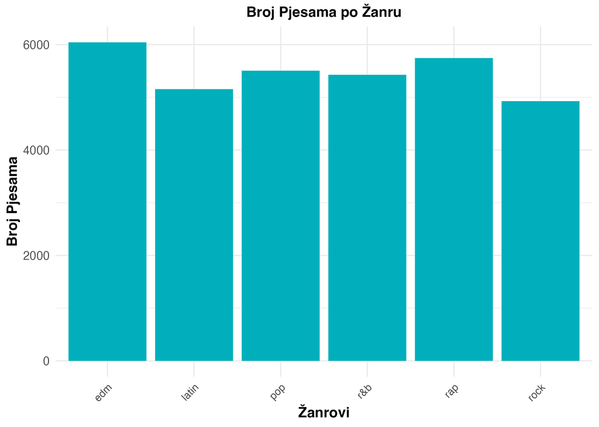

**Analiza grafa**

Graf “Broj Pjesama po Žanru” vizualno prikazuje raspodjelu glazbenih žanrova Spotify datasetu. Svaki stupac na grafu predstavlja određeni glazbeni žanr, dok visina stupca odražava broj pjesama u tom žanru.

Ovaj graf pruža početni uvid u glazbene preferencije i raznolikost žanrova među pjesmama na Spotifyju. Dominantni žanrovi mogu ukazivati na popularnost određenih glazbenih stilova među korisnicima platforme.

Budući da je najpopulanriji edm (Electro dance music), prikazat ćemo njegovu popularnost kroz godine

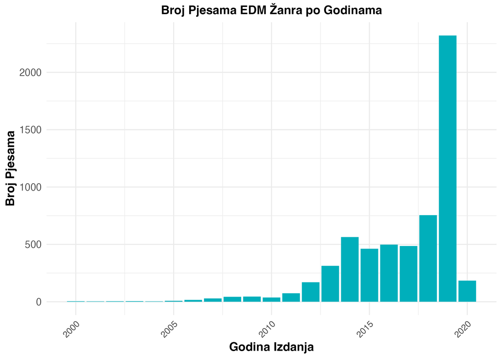

**Analiza grafa**

Graf “Broj Pjesama EDM Žanra po Godinama” vizualno prikazuje raspodjelu glazbenog žanra EDM (Electro dance music) nad Spotify datasetom. Svaki stupac na grafu predstavlja određenu godinu, dok visina stupca odražava broj pjesama u toj godini.

Iz priloženog grafa može se zaključiti kako je edm (Electro dance music) postao sve više popularan tek od 2012 godine, te od tada sve više preuzima mainstream glazbe na Spotifyu.

**Najpopularniji izvodaci**

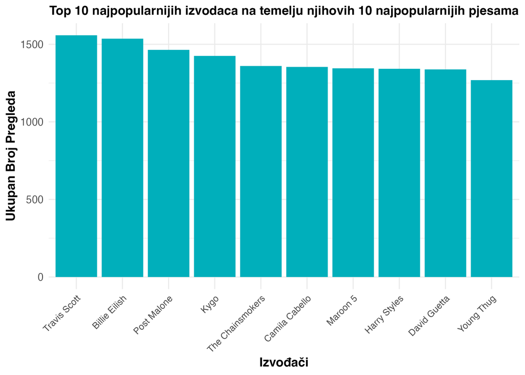

**Analiza grafa**

Grafički prikaz ukupnog broja pregleda temeljem 10 najpopularnijih pjesama svakog izvođača pruža zanimljiv uvid u popularnost umjetnika na Spotify platformi. Analizirajući graf, uočavamo da je Travis Scott apsolutni lider među izvođačima, slijedi ga Billie Eilish, Post Malone te ostali.

**Najpopularnije pjesme Travis Scotta**

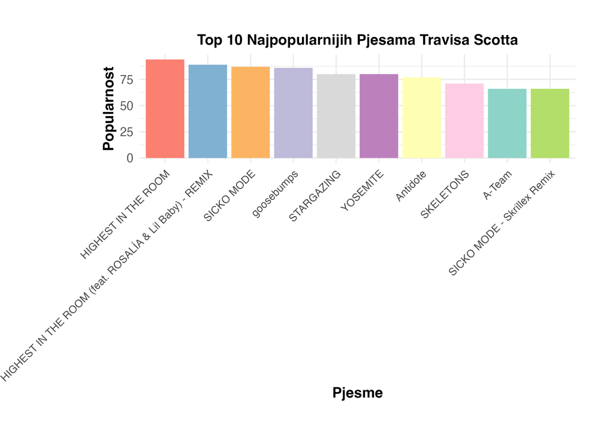

**Analiza grafa**

Ova analiza naglašava impresivnu popularnost Travisa Scotta na Spotify platformi, pri čemu se ističe njegov utjecaj kroz deset najpopularnijih pjesama. “Highest in the Room” dominira među njima, zatim slijedi istoimeni Remix, “Sicko mode” i ostali. Presudila je njegova konstantnost jer nije samo bljesnuo s jednom pjesmom, već u svima drži jako visoku kvalitetu izvedbe.

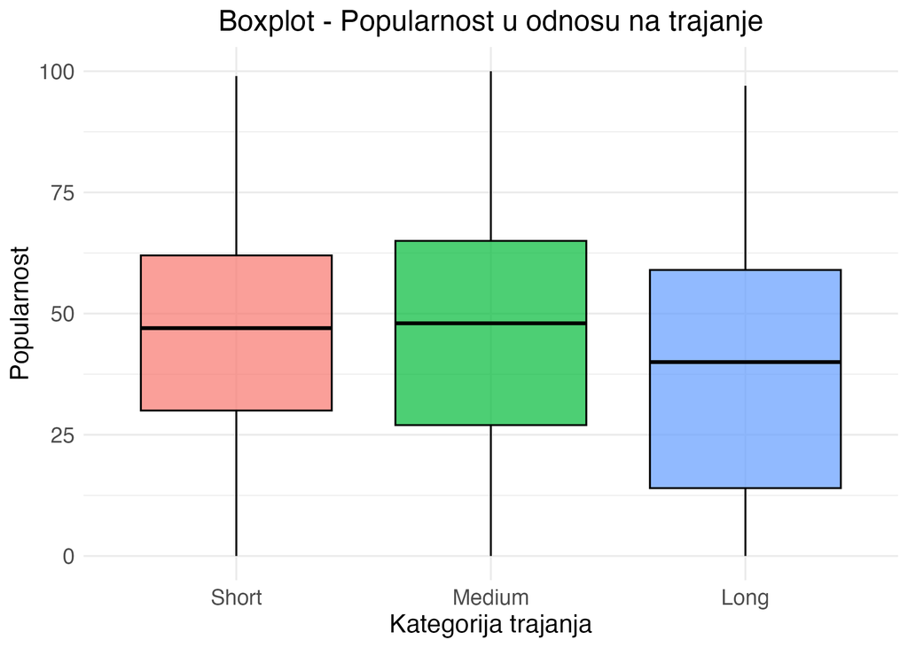

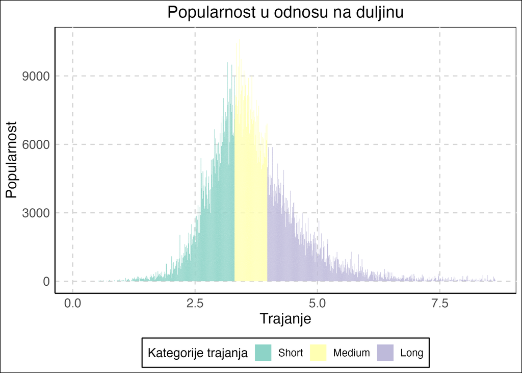

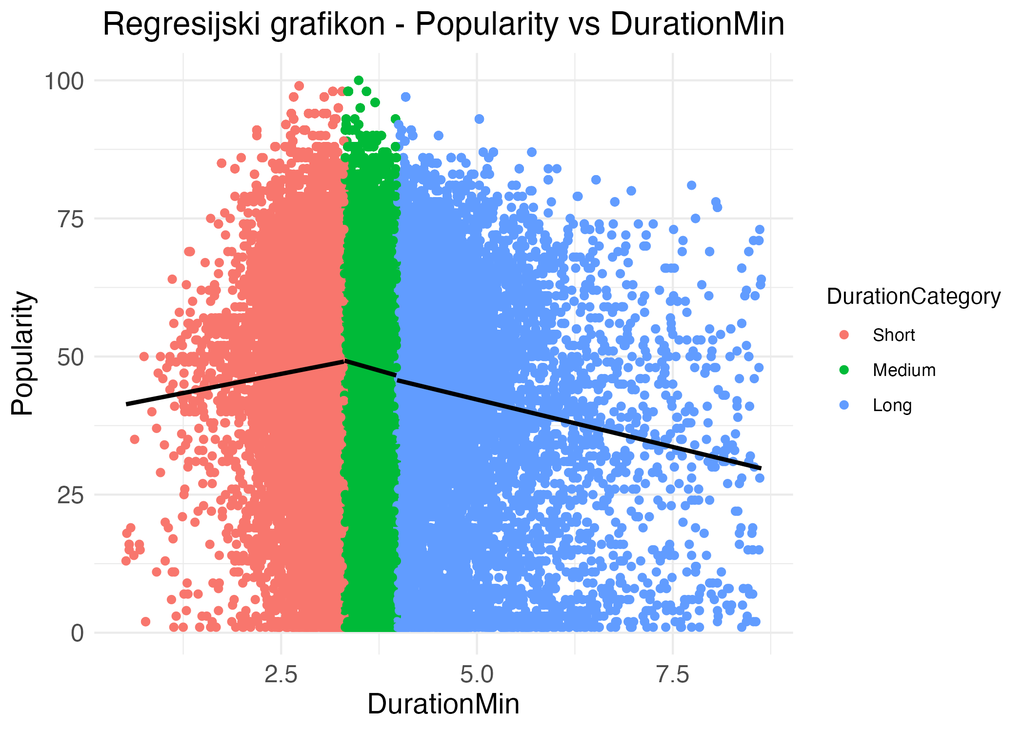

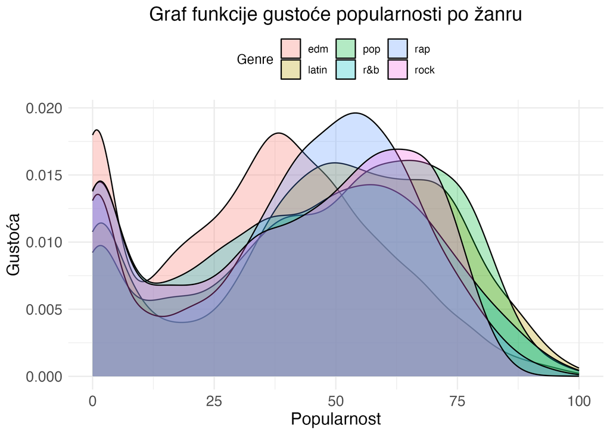

**Analiza grafa**

Iz grafa “Graf funkcije gustoće popularnosti po žanru” možemo zaključiti da većinom funkcije gustoća svih žanrova donekle prate normalnu razdiobu, stime da sve imaju veliku devijaciju u lijevom repu. Naime Žanr “edm” ima najviše malo popularnih pjesama, dok “pop” najmanje. Najviše srednje ocjenjenih pjesama pripadaju žanru “rap”, dok u najbolje ocjenjenim pjesmama prednjači žanr “latin”

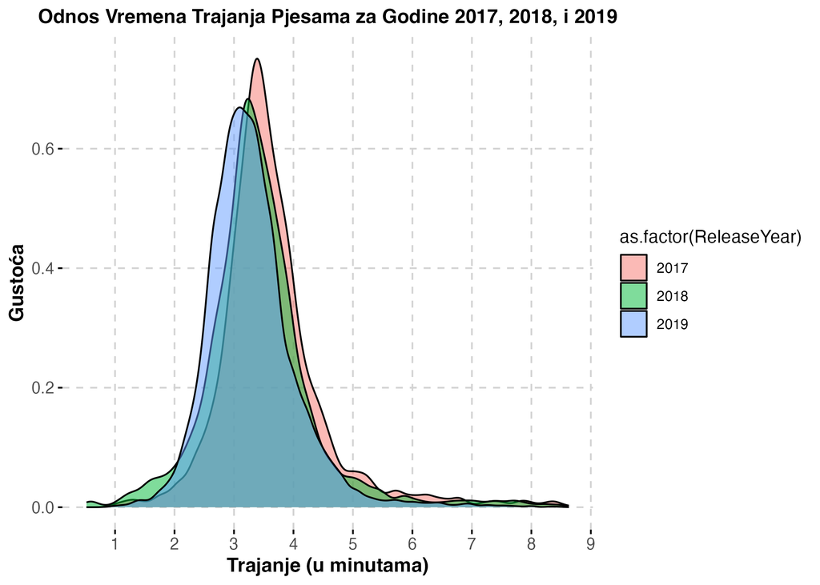

**Analiza grafa**

Iz analize grafa odnosa vremena trajanja pjesama za godine 2017., 2018. i 2019., uočavamo da je za sve tri godine najveći broj pjesama trajao između 3 i 4 minute. Ovaj trend posebno je izražen u 2017. godini, gdje gustoća pjesama u tom vremenskom intervalu dominira u usporedbi s preostalim godinama. Primjećujemo i značajan porast broja kraćih pjesama, od 2 do 3 minute, tijekom 2019. godine, čime se nastavlja trend započet u 2018. godini. Takve kraće pjesme karakterizirane su lakoćom pamćenja i postaju sve popularnije s godinama. U skladu s navedenim, zaključujemo da je s vremenom postao popularniji i učestaliji tip pjesama koji traje kraće, trenutno najpopularniji oko 3 minuta, no s tendencijom pada vremena izvođenja.

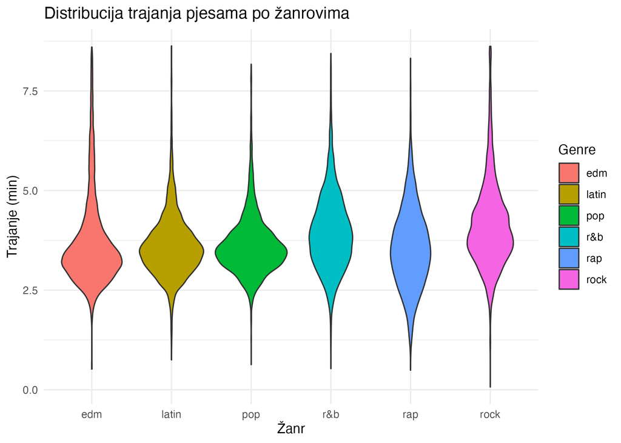

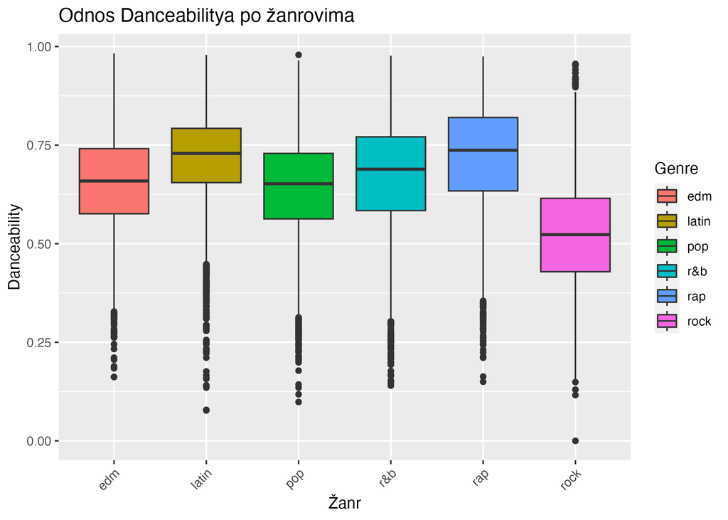

**Analiza grafa**

Graf “Odnos Danceabilitya po Žanrovima” pruža vizualni uvid u raspodjelu danceabilitya među različitim glazbenim žanrovima. Svaki žanr predstavljen je na x-osi, dok je danceability prikazan na y-osi, čime se omogućava usporedba plesnosti među žanrovima. Gledajući graf možemo vidno primjetiti kako rock žanr ima daleko najniži prosječni danceability, što odražava njegove karakteristične glazbene elemente manje prikladne za ples. S druge strane, rap i latin se izdvajaju kao žanrovi s najvišim prosječnim danceabilityem, sugerirajući da glazba u ovim žanrovima često potiče na ples i dinamičnost.